# STAT 687 - Chapter 5

Other Parametric Distributions

Maj Jason Freels

Air Force Institute of Technology

## This chapter explains

STAT 687 - Chapter 5

This chapter is a continuation of Chapter 4, describing more advanced parametric distributions

The properties and importance of various parametric distributions that cannot be transformed into a location-scale distribution

Threshold-parameter distributions

How some statistical distributions can be determined by applying basic ideas of probability theory to physical properties of a failure process, system, or population of units

# Section 5.2|Gamma Distribution

## $\text{For}\; T \sim GAM(\theta,\kappa),\;\;T \in [0,\infty)$

STAT 687 - Chapter 5

$\begin{aligned} f(t|\theta,\kappa)&=\frac{1}{\Gamma(\kappa)\theta}\left(\frac{t}{\theta}\right)^{\kappa-1}\\\\ F(t|\theta,\kappa)&=\Gamma_{I}\left(\frac{t}{\theta},\kappa\right)\\\\ t_{p}&=\theta\Gamma_{I}^{-1}(p,\kappa)\\\\ E[T]&=\kappa\theta\\\\ Var[T]&=\kappa\theta^2 \end{aligned}$

Where $\Gamma_{I}(x,a)\equiv$ the (lower) incomplete gamma function in R `gsl::gamma_inc(x,a)`

## $\S$ 5.3 - Gamma Distribution

STAT 687 - Chapter 5

# Section 5.3|Generalized Gamma Distribution

## $\text{For}\; Y \sim GENG(\theta,\beta, \kappa),\;\;Y\in(0,\infty)$

STAT 687 - Chapter 5

$\begin{aligned} f(t|\theta,\beta,\kappa)&=\Gamma_{I}\left[\left(\frac{t}{\theta}\right)^{\beta},\kappa\right]\\\\ F(y|\theta,\beta,\kappa)&=\frac{\beta}{\Gamma(\kappa)\theta}\left(\frac{t}{\theta}\right)^{\kappa\beta-1}\exp\left[-\left(\frac{t}{\theta}\right)^{\beta}\right]\\\\ t_{p}&=\theta \left[\Gamma_{I}^{-1}(p;\kappa)\right]^{1/\beta}\\\\ E[Y]&=\frac{\theta\Gamma(1/\beta+\kappa}{\Gamma(\kappa)}\\\\ Var[Y]&=\theta^2\left[\frac{\Gamma(2/\beta+\kappa)}{\Gamma(\kappa)}-\frac{\Gamma^{2}(1/\beta)+\kappa}{\Gamma^{2}(\kappa)}\right] \end{aligned}$

## $\S$ 5.3 - Generalized Gamma Distribution

STAT 687 - Chapter 5

$f(t|\theta,\beta,\kappa)=\Gamma_{I}\left[\left(\frac{t}{\theta}\right)^{\beta};\kappa\right]$

Special cases for $T \sim GENG(\theta,\beta,\kappa)$

- When $\beta = 1, \;\;\; T \sim GAM(\theta,\kappa)$
- When $\kappa = 1, \;\;\; T \sim WEIB(\theta,\beta)$
- When $(\beta,\kappa) = (1,1), \;\;\; T \sim EXP(\theta)$
- As $\kappa \rightarrow \infty, \;\;\; T\xrightarrow{d} LOGNOR(\log(\theta)+\log(\kappa)/\beta, 1/(\beta\sqrt{\kappa}))$

## $\S$ 5.3 - Generalized Gamma Distribution

STAT 687 - Chapter 5

# Section 5.4|Extendend Generalized Gamma Distribution

## $\text{For}\; T \sim EGENG(\mu,\sigma, \lambda),\;\;T\in[0,\infty)$

STAT 687 - Chapter 5

$\begin{aligned} f(t|\mu,\sigma,\lambda)&=\begin{cases} \frac{\lambda}{\sigma t} \phi_{lg}\left[\lambda\omega+ \ln(\lambda^{-2}); \lambda^{-2}\right] &\mbox{if } \lambda \ne 0\\\\ \frac{1}{\sigma t} \phi_{nor}(\omega) &\mbox{if } \lambda = 0 \end{cases}\\\\ F(t|\mu,\sigma,\lambda)&=\begin{cases}\Phi_{lg}\left[\lambda\omega+ \ln(\lambda^{-2}); \lambda^{-2}\right] &\mbox{if } \lambda > 0\\\\ \Phi_{nor}(\omega) &\mbox{if } \lambda = 0\\\\ 1-\Phi_{lg}\left[\lambda\omega+\ln(\lambda^{-2});\lambda^{-2}\right]&\mbox{if }\lambda <0\end{cases}\\\\ t_{p}&=\exp\left[\mu+\sigma\times \omega(p;\lambda)\right]\\\\ E[T]&=\exp(\mu+0.5\sigma^2)\\\\ Var[T]&=\exp(2\mu+\sigma^2)(\exp(\sigma^2)-1) \end{aligned}$

## $\S$ 5.4 - Extended Generalized Gamma Dist.

STAT 687 - Chapter 5

For $T\sim EGENG(\mu,\sigma,\lambda)$ the following special cases exist

- If $\lambda>0,\;\;\;\;\;\;\; T \sim GENG(\mu, \sigma,\lambda)$
- If $\lambda=1,\;\;\;\;\;\;\;T \sim WEIB(\mu,\sigma)$
- If $\lambda=0,\;\;\;\;\;\;\; T \sim LOGNOR(\mu,\sigma)$
- If $\lambda=-1,\;\;\;\; T^{-1} \sim WEIB(-\mu,\sigma), \text{ aka the Frechet distribution }$
- If $\lambda=\sigma,\;\;\;\;\;\;\; T \sim GAM(\theta,\kappa), \text{ where } \theta=\lambda^2\exp(\mu)\text{ and } \kappa=\lambda^{-2}$
- If $\lambda=\sigma=1, T \sim EXP(\theta), \text{ where } \theta=\exp(\mu)$$

## $\S$ 5.4 - Extended Generalized Gamma Dist.

STAT 687 - Chapter 5

# Section 5.6|Inverse Gaussian Distribution

## $\text{For}\; T \sim IGAU(\theta,\beta),\;\;T\in[0,\infty)$

STAT 687 - Chapter 5

$\begin{aligned} f(t|\mu,\sigma)&=\frac{\sqrt{\beta}}{\exp(z/2)}\phi_{nor}\left(\sqrt{\beta}\left[\frac{\exp(z)-1}{\exp(z/2)}\right]\right)\\\\ F(t|\mu,\sigma)&=\Phi_{nor}\left(\sqrt{\beta}\left[\frac{\exp(z)-1}{\exp(z/2)}\right]\right)+\exp(2\beta)\Phi_{nor}\left(-\sqrt{\beta}\left[\frac{\exp(z)+1}{\exp(z/2)}\right]\right)\\\\ t_{p}&=\theta\exp\left[\mu+\Phi^{-1}_{ligau}(p;\beta)\right]\\\\ E[T]&=\theta\\\\ Var[T]&=\theta/\beta^2 \end{aligned}$

## $\S$ 5.6 - Inverse Gaussian Distribution

STAT 687 - Chapter 5

# Section 5.7|Birnbaum-Saunders Distribution

## $\text{For}\; T \sim BISA(\theta,\beta),\;\;T\in[0,\infty)$

STAT 687 - Chapter 5

$\begin{aligned} f(t|\mu,\sigma)&=\frac{\sqrt{\frac{t}{\theta}}+\sqrt{\frac{\theta}{t}}}{2\beta t} \phi_{nor}\left(z)\right)\\\\ F(t|\mu,\sigma)&=\Phi_{nor}\left(z\right)\\\\ t_{p}&=\frac{\theta}{4}\left[\beta\Phi^{-1}_{nor}(p)+\sqrt{4+\left[\beta\Phi_{nor}^{-1}(p) \right]^2}\right]^2\\\\ E[T]&=\theta\left(1+\frac{\beta^2}{2}\right)\\\\ Var[T]&=(\theta\beta)^2\left(1+\frac{5\beta^2}{4}\right) \end{aligned}$

## $\S$ 5.7 - Birnbaum-Saunders Distribution

STAT 687 - Chapter 5

# Section 5.8|Gompertz-Makeham Distribution

## $\text{For}\; T \sim GOMA(\theta,\zeta, \eta),\;\;T\in[0,\infty)$

STAT 687 - Chapter 5

$\begin{aligned} f(t|\theta,\zeta,\eta)&=\frac{1}{t}\phi_{lgoma}\left[\ln\left(\frac{t}{\theta}\right);\zeta,\eta\right]\\\\ F(t|\theta,\zeta,\eta)&=\Phi_{lgoma}\left[\ln\left(\frac{t}{\theta}\right);\zeta,\eta\right]\\\\ h(t|\theta,\zeta,\eta)&=\frac{\eta}{\theta}+\frac{\exp(-\zeta)}{\theta}\exp\left(\frac{t}{\theta}\right)\\\\ t_{p}&=\theta\exp\left[\Phi^{-1}_{lgoma}(p;\zeta,\eta)\right] \end{aligned}$

## $\S$ 5.8 - Gompertz-Makeham Distribution

STAT 687 - Chapter 5

# Section 5.10|Distributions With a Threshold Parameter

## $\S$ 5.10.1 - Background

STAT 687 - Chapter 5

Many of the distributions introduced up to this point are defined on $\mathcal{R}^+$

- Most log-location scale distributions
- Some of the more complex distributions

For these distributions, $F(t)$ begins increasing at $t=0$

Each of these distributions can be generalized by adding a **threshold parameter**,$\gamma\ge0$

If $\gamma>0$ the entire distribution is shifted by a value equal to $\gamma$

- Denotes that failures **cannot** occur $\forall t< \gamma$
- This can be useful for fitting distribution that are highly right-skewed

## Figure 5.6

STAT 687 - Chapter 5

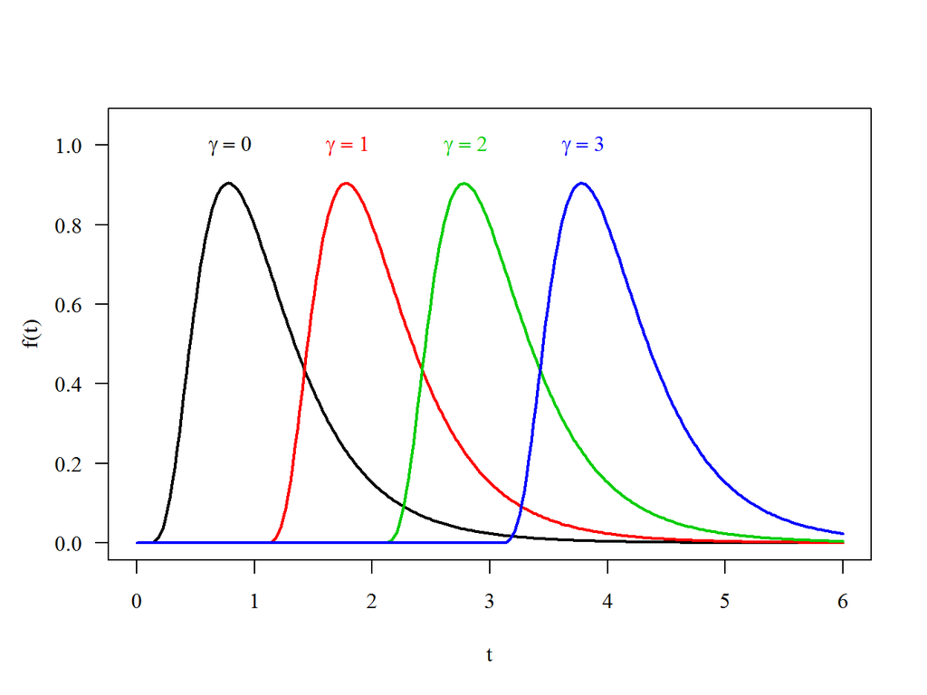

## Figure 5.6

STAT 687 - Chapter 5

```r
par(bg = NA, family = "serif")
curve(dlnorm(x,  0,0.5), lwd=2, col=1, n=300, xlim=c(0,6), ylim=c(0,1.05),
      xlab="t", yaxt="n", ylab = "")
curve(dlnorm(x-1,0,0.5), lwd=2, col=2, n=300, add = TRUE)
curve(dlnorm(x-2,0,0.5), lwd=2, col=3, n=300, add = TRUE)
curve(dlnorm(x-3,0,0.5), lwd=2, col=4, n=300, add = TRUE)
axis( side = 2, las = 1)
mtext(side = 2, "f(t)", line = 2.5)
text(seq(.797,3.797),rep(1,4), c(parse(text = "gamma==0"),
                                 parse(text = "gamma==1"),
                                 parse(text = "gamma==2"),
                                 parse(text = "gamma==3")),
     col = 1:4, font = rep(2,4))
```

## $\S$ 5.11.2 Generalized Threshold-Scale cdf & pdf

STAT 687 - Chapter 5

The form of the cdf for the generalized threshold-scale (GETS) distribution is

$F(t,\alpha, \sigma,\xi)=\begin{cases}\Phi\left[\log(1+\sigma z)^{1/\sigma}\right] &\mbox{for } \sigma>0, z>-1/\sigma\\\\ \Phi(z) &\mbox{for } \sigma=0,z\in(\infty,\infty)\\\\ 1-\Phi\left[\log(1+\sigma z)^{1/|\sigma|}\right] &\mbox{for } \sigma<0, z<-1/\sigma\end{cases}$

where

$\begin{aligned} \Phi &\equiv \text{ Form of generic cdf with standard parameter values}\\\\ z&=\frac{t-\alpha}{\xi}\\ \sigma &\in(-\infty,\infty)\\\\ \alpha &\in (-\infty,\infty)\\\\ \xi&>0 \end{aligned}$

## $\S$ 5.11.2 Generalized Threshold-Scale cdf & pdf

STAT 687 - Chapter 5

The form of the pdf for the generalized threshold-scale (GETS) distribution is

$f(t,\alpha, \sigma,\xi)=\begin{cases}\phi\left[\log(1+\sigma z)^{1/|\sigma|}\right]\times \frac{1}{\xi(1+\sigma z)} &\mbox{for } \sigma\ne 0\\\\ \phi(z) \times \frac{1}{\xi} &\mbox{for } \sigma=0\\ \end{cases}$

Finally, inverting the GETS cdf gives the quantile function

$t_{p}=\alpha +\xi\times w(\sigma,p)$

where

$w(\sigma,p)=\begin{cases}\frac{\exp\left[\sigma\Phi^{-1}(p)\right]-1}{\sigma} &\mbox{for } \sigma>0\\\\ \Phi^{-1}(p) &\mbox{for } \sigma=0\\\\ \frac{\exp\left[|\sigma|\Phi^{-1}(1-p)\right]-1}{\sigma} &\mbox{for } \sigma<0\end{cases}$

## $\S$ 5.11.4 Special Cases of the GETS Distribution

STAT 687 - Chapter 5

Recall from Chapter 4, the location-scale form of the normal, SEV, and LEV distributions

$\begin{aligned} F(t|\alpha,0,\xi)&=\Phi_{nor}\left[\frac{t-\alpha}{\xi}\right]\\\\ F(t|\alpha,0,\xi)&=\Phi_{sev}\left[\frac{t-\alpha}{\xi}\right]\\\\ F(t|\alpha,0,\xi)&=\Phi_{lev}\left[\frac{t-\alpha}{\xi}\right] \end{aligned}$

## $\S$ 5.11.4 Special Cases of the GETS Distribution

STAT 687 - Chapter 5

The threshold log-location-scale form of the NOR-GETS, SEV-GETS, and LEV-GETS distributions are

$\begin{aligned} F(t|\alpha,0,\xi)&=\Phi_{nor}\left[\frac{\log(t-\gamma)-\alpha}{\xi}\right]\\\\ F(t|\alpha,0,\xi)&=\Phi_{sev}\left[\frac{\log(t-\gamma)-\alpha}{\xi}\right]\\\\ F(t|\alpha,0,\xi)&=\Phi_{lev}\left[\frac{\log(t-\gamma)-\alpha}{\xi}\right] \end{aligned}$

Where $\gamma=\alpha-\xi/\sigma \text{ and } \mu=\log(\xi/\sigma)$

## $\S$ 5.11.4 NOR-GETS Distribution

STAT 687 - Chapter 5

## $\S$ 5.11.4 SEV-GETS Distribution

STAT 687 - Chapter 5

## $\S$ 5.11.4 LEV-GETS Distribution

STAT 687 - Chapter 5

# Section 5.12|Other Methods of Deriving Failure-Time Distributions

## $\S$ 5.12 - Other Methods of Deriving $F(t)$

STAT 687 - Chapter 5

The basic idea behind these methods is to model the physical/chemical process that cause failure

*Mixture distributions*

- Arise if a data set contains observations from two or more distinct processes
- Mixtures can be finite or continuous

*Power Distributions*

- Distributions of minima and maxima of $iid$ random variables have important applications
- Are related to reliability block diagrams (series/parallel components)

*Physical/Chemical Degradation Distributions* Chapters 13 & 18

## $\S$ 5.12 - Mixture Distributions

STAT 687 - Chapter 5

Mixture distributions result

- If a population of products are manufactured using differnt processes
- If a population of products are manufactures using different raw materials
- If a population of products operates in distinctly different environments

## $\S$ 5.12 - Finite Mixture Distributions

STAT 687 - Chapter 5

**Suppose we are interested in testing the fracture toughness of a new glass material to be used in future touchscreens**

- **Fracture toughness:** total energy that a material can absorb before fracture
- Greater toughness implies that if a phone is dropped the screen could flex and absorb the impact energy without cracking
- **Test:** apply specified load to material samples every second until fracture occurs
- **Response of interest:** number of load cycles at fracture $N$
- Distribution failure cycles will be compared to legacy materials

## $\S$ 5.12 - Finite Mixture Distributions

STAT 687 - Chapter 5

**Further suppose that**

- 60% of the specimens were manufactured using materials from Supplier A
- The other 40% were manufactured using materials from Supplier B
- The Supplier B specimens contain contaminants, thus $(E[N_{A}] \ne E[N_{B}])$

- If the failure time distributions of both samples have the same form (come from the same distribution family)
- $\mu_{A},\mu_{B},\;\text{and}\;\sigma$ are estimated separately

## $\S$ 5.12 - Continuous Mixture Distributions

STAT 687 - Chapter 5

It’s unlikely that the level of contaminant in the specimens will only have two levels

- We’d expect the level of contaminant to fall on a continuous spectrum
- We’d also expect the level of contaminant across the population of specimens to follow some distribution

This more general case results in a continuous mixture distribution, where

$\begin{aligned} F(N|\mu,\sigma,\mathbf{\theta})=P(N\le n)&=\int_{-\infty}^{\infty}P(N\le n|\mu=\mu_{1},\sigma)f_{\mu_{1}}(\mu_1|\mathbf{\theta})d\mu_{1}\\\\ &=\int_{-\infty}^{\infty}F_{N|\mu=\mu_{1}}(n|\mathbf{\mu},\sigma,\mathbf{\theta})f_{\mu_{1}}(\mu_1|\mathbf{\theta})d\mu_{1} \end{aligned}$

and

$f(N|\mu,\sigma,\mathbf{\theta})=\int_{-\infty}^{\infty}f_{N|\mu=\mu_{1}}(n|\mathbf{\mu},\sigma,\mathbf{\theta})f_{\mu_{1}}(\mu_1|\mathbf{\theta})d\mu_{1}$

## $\S$ 5.12 - Minimum-Type Distributions

STAT 687 - Chapter 5

For components in series, the system fails when ANY component fails

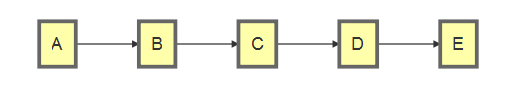

the system cdf $F_{system}(t)$ can be expressed as

$P(T_{system}\le t)=1-P(T_{A}>t)\cap P(T_{B}>t)\cap P(T_{C}>t)\cap P(T_{D}>t)\cap P(T_{E}>t)$

**BUT**, if we can reasonably assume independence among the components…i.e.

$P(T_{A}>t)\perp P(T_{B}>t)\perp P(T_{C}>t)\perp P(T_{D}>t)\perp P(T_{E}>t)$

then $F_{system}(t)$ becomes

$P(T_{system}\le t)=1-P(T_{A}>t)\times P(T_{B}>t)\times P(T_{C}>t)\times P(T_{D}>t)\times P(T_{E}>t)$

## $\S$ 5.12 - Minimum-Type Distributions

STAT 687 - Chapter 5

Example: $T_{A,B,C,D,E} \sim i.i.d EXP(\theta = 2)$

$\begin{aligned} F_{system}(T)&=1-\exp\left[-0.5t\right]\exp\left[-0.5t\right]\exp\left[-0.5t\right]\exp\left[-0.5t\right]\exp\left[-0.5t\right]\\\\ &=1-\exp\left[-(0.5+0.5+0.5+0.5+0.5)t\right]\\\\ &=1-\exp\left[-2.5t\right] \end{aligned}$

Therefore, we see that for a system with

- $n = 1,2,...$ components - arranged in series
- Where the lifetime of each component $T_{i}\sim EXP(\theta_{i}), \;\;i= 1,2,...n$

## For items in series, $S(t_{i})\le\min S_{i}(t_{i})$

STAT 687 - Chapter 5

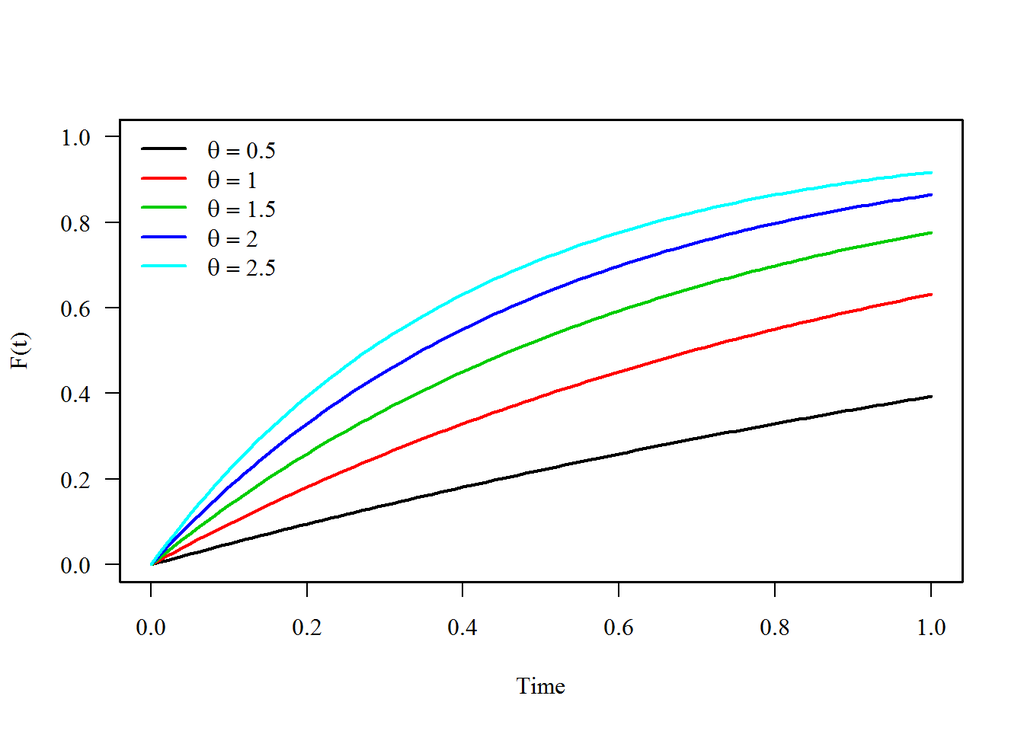

## For items in series, $S(t_{i})\le\min S_{i}(t_{i})$

STAT 687 - Chapter 5

```r
par(family = "serif", bg = NA)
curve(pexp(x,0.5), yaxt = "n", xlab = "Time", ylab = "F(t)", lwd = 2, ylim = c(0,1))
curve(pexp(x,1.0), col = 2, lwd = 2, add = TRUE)
curve(pexp(x,1.5), col = 3, lwd = 2, add = TRUE)
curve(pexp(x,2.0), col = 4, lwd = 2, add = TRUE)
curve(pexp(x,2.5), col = 5, lwd = 2, add = TRUE)
axis(side = 2, las = 1)
box(lwd = 1.5)
legend("topleft", c(expression(theta==0.5),expression(theta==1.0),
                    expression(theta==1.5),expression(theta==2.0),
                    expression(theta==2.5)),
       lwd = 2, col = 1:5, bty = "n")
```

## $\S$ 5.12 - Maximum-Type Distributions

STAT 687 - Chapter 5

For components in parallel, the system fails when ALL of the components fail

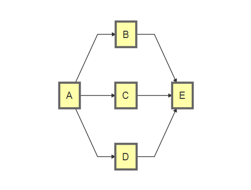

## $\S$ 5.12 - Maximum-Type Distributions

STAT 687 - Chapter 5

The system cdf $F_{system}(t)$ for components in parallel can be expressed as

$P(T_{system}\le t)=P(T_{B}\le t)\cap P(T_{C}\le t)\cap P(T_{D}\le t)$

**AGAIN**, if we can assume independence among the components…i.e.

$P(T_{B}\le t)\perp P(T_{C}\le t)\perp P(T_{D}\le t)$

then $F_{system}(t)$ becomes

$\begin{aligned} P(T_{system}\le t)&=P(T_{B}\le t)\times P(T_{C}\le t)\times P(T_{D}\le t)\\\\ &=\prod_{i=1}^n P(T_{i}\le t) \end{aligned}$

## $\S$ 5.12 - Maximum-Type Distributions

STAT 687 - Chapter 5

Example: $T_{B,C,D} \sim i.i.d EXP(\theta = 2)$

$\begin{aligned} F_{system}(T)&=(1-\exp\left[-0.5t\right])(1-\exp [-0.5t])(1-\exp \left[-0.5t\right])\\\\ &=1 - 2\exp [-0.5t]+ \exp [-t] (1-\exp [-0.5t])\\\\ &=1-3\exp\left[-0.5t\right]+3\exp [-t]-\exp [-1.5t] \end{aligned}$

Therefore, we see that for a system with

- $n = 1,2,...$ components arranged in parallel
- Where the lifetime of each component $T_{i}\sim EXP(\theta_{i}), \;\;i= 1,2,...n$

The system lifetime $T_{system}$ is not exponential

## For items in parallel, $S(t_{i})\ge\max S_{i}(t_{i})$

STAT 687 - Chapter 5

[figure not shown]

## For items in parallel, $S(t_{i})\ge\max S_{i}(t_{i})$

STAT 687 - Chapter 5

```r
par(family = "serif", bg = NA)
curve(pexp(x,0.5), yaxt = "n", xlab = "Time", ylab = "F(t)", lwd = 2, ylim = c(0,1))
curve(pexp(x,1.0), col = 2, lwd = 2, add = TRUE)
curve(pexp(x,1.5), col = 3, lwd = 2, add = TRUE)
curve(pexp(x,2.0), col = 4, lwd = 2, add = TRUE)
curve(pexp(x,2.5), col = 5, lwd = 2, add = TRUE)
axis(side = 2, las = 1)
box(lwd = 1.5)
legend("topleft", c(expression(theta==0.5),expression(theta==1.0),
                    expression(theta==1.5),expression(theta==2.0),
                    expression(theta==2.5)),
       lwd = 2, col = 1:5, bty = "n")
```